# 7_data_vis_2 slides

```python
import numpy as np
import matplotlib.pyplot as plt
```

## Random Number Generation in Python and Common Plot Types

- Data we will generate throughout the course is pseudorandom
  - Generated using an algorithm for generating seemingly random but still reproducible data.

`They start with a random number, known as the seed, and then use an algorithm to generate a pseudo-random sequence of bits based on it.`

- should not be used for security purposes but is actually recommended for data science
  - Reproducibility if random sequencing is convenient in experiments
- Basic radnom functionality is implemented in the `random` standard library
- Many other sampling strategies (probability distributions) are implemented un `numpy`
  - The same functions available in `random` are also available in `python`, although generally with more options
  - `numpy` offer more strategies (beyond uniform)

### (Pseudo)-Random Number Generation and Seeds

- The seed and and the strategu determine the sequence of randomly generated numbers
  - Suppose the strategy he is *uniform* in range `[0,100]`

[figure not shown]

```python
import random
random.seed(2)
random.randint(0,100)
```

```
7
```

```python
# Random sampling after setting a seed
random.seed(2)
rand_numbers = []
for i in range(10):
    rand_numbers.append(random.randint(0,100))
print(rand_numbers)
```

```
[7, 11, 10, 46, 21, 94, 85, 39, 32, 77]
```

```python
# Random sampling without setting a seed
rand_numbers = []
for i in range(20):
    rand_numbers.append(random.randint(0,100))
print(rand_numbers)
```

```
[27, 77, 4, 74, 87, 20, 55, 81, 50, 92, 65, 47, 69, 56, 64, 34, 4, 3, 46, 59]
```

```python
# Random sampling after  resetting a seed
# Random sampling after setting a seed
random.seed(2)
rand_numbers = []
for i in range(10):
    rand_numbers.append(random.randint(0,100))
print(rand_numbers)
```

```
[7, 11, 10, 46, 21, 94, 85, 39, 32, 77]
```

### Useful `random` Functions

- `random.seed(s)`: Set the seed to `s`
- `random.ranint(l, u)` : Generate a random int in the range [l, u]
- `random.random()` : Generate a random value in the range [0, 1[
- `random.choice(items)`: Select a random item from the items
- `random.choices(items, k=n)`: Select `n` random items from the items (with replacement)
- `random.sample(items, k=n)`: Sample `n <= len(items)` random items from the items (without replacement)
- `random.shuffle(items)`: Shuffle, in-place, the `items` in a pseudo random fashion

```python
random.seed(42)
random.choice(["CS", "Math", "Eng", "Econ"])
```

```
'CS'
```

```python
random.seed(42)
random.choices(["CS", "Math", "Eng.", "Econ"], k=2)
```

```
['Eng.', 'CS']
```

```python
random.seed(42)
random.sample(["CS", "Math", "Eng.", "Econ"], k=2)
```

```
['CS', 'Econ']
```

```python
items = [1,2,3,4,5,6]
random.shuffle(items)
print(items)
```

```
[3, 5, 2, 6, 4, 1]
```

### Equivalent `numpy` Functions

```python
np.random.randint(0,10, 10)
```

```
array([4, 2, 6, 4, 8, 6, 1, 3, 8, 1])
```

```python
np.random.rand(10)
```

```
array([0.37522502, 0.6661122 , 0.48506243, 0.34982926, 0.67729909,
       0.00224848, 0.00743588, 0.73737078, 0.44326694, 0.69569514])
```

```python
# rand, sample and random_sample have the same default behavior
np.random.seed(42)
print(np.random.sample(10))
print("-------------------------")
np.random.seed(42)
print(np.random.random_sample(10))
print("-------------------------")
np.random.seed(42)
print(np.random.rand(10))
```

```
[0.37454012 0.95071431 0.73199394 0.59865848 0.15601864 0.15599452
 0.05808361 0.86617615 0.60111501 0.70807258]
-------------------------
[0.37454012 0.95071431 0.73199394 0.59865848 0.15601864 0.15599452
 0.05808361 0.86617615 0.60111501 0.70807258]
-------------------------
[0.37454012 0.95071431 0.73199394 0.59865848 0.15601864 0.15599452
 0.05808361 0.86617615 0.60111501 0.70807258]
```

```python
items = [1,2,3,4,5,6]
random.shuffle(items)
items
```

```
[5, 6, 4, 1, 3, 2]
```

### Basic Plot Types: Line Plot

- Data points plotted as a line
- Typically used when the x-axis is continuous or when it's acceptable to make such an assumption
  - ex.: `x` time-series data
- Multiple lines can be combined for comparison
  - Lines can have different styles
  - Solid by default, and add different styles when plotting more than one line

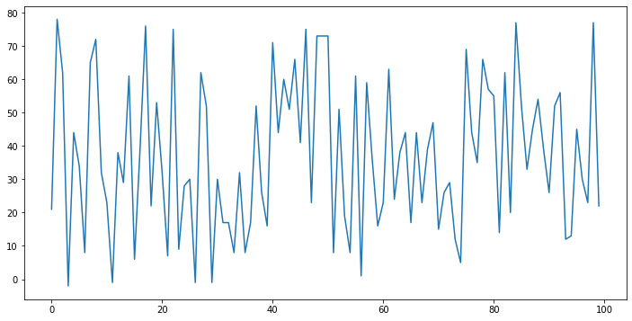

```python
plt.figure(figsize=(12,6))

year = np.arange(0,100)
profit = np.random.randint(-2,80, 100)
plt.plot(year, profit)
```

### Basic Plot Types: Scatter Plot

- Show multiple dimensions (typically two) of the data
- Each mark is a data instance and is associated with an `x` and `y` value.
  - Data points plotted as dots, circles, or other symbols across two axes.
- Typically used when:
  - Data represent multiple entities
  - Values on the x-axis are continuous or discrete but not sparse
- Can include more than two dimensions
  - Symbols can use different shapes to represent a third, typically categorical variable
  - Symbols can use size or hue to represent a third continue variable
- More than three is typically not recommended

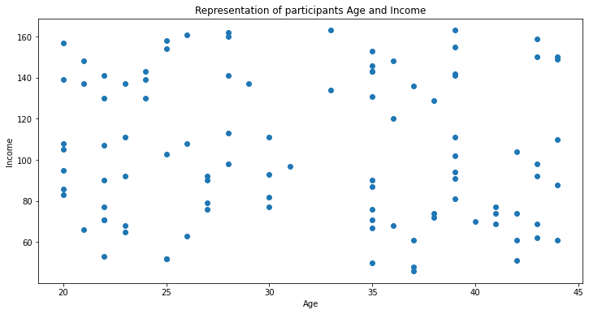

```python
age = np.random.randint(20, 45, 100)
income = np.random.randint(45, 165, 100)


plt.figure(figsize=(12,6))
plt.scatter(age, income)

plt.xlabel("Age")
plt.ylabel("Income")
plt.title("Representation of participants Age and Income")
```

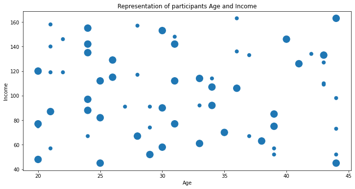

```python
age = np.random.randint(20, 45, 100)
income = np.random.randint(45, 165, 100)
credit_score = np.random.choice([0, 50, 200], 100)

plt.figure(figsize=(12,6))
plt.scatter(age, income, s=credit_score)

plt.xlabel("Age")
plt.ylabel("Income")
plt.title("Representation of participants Age and Income")
```

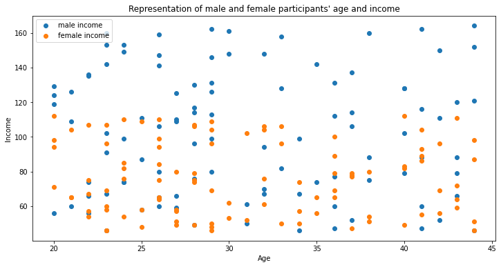

```python
plt.figure(figsize=(12,6))

age = np.random.randint(20, 45, 100)
income_male = np.random.randint(45, 165, 100)
income_female = np.random.randint(45, 115, 100)
plt.scatter(age, income_male, label= "male income")
plt.scatter(age, income_female, label= "female income")

plt.legend()

plt.xlabel("Age")
plt.ylabel("Income")
_ = plt.title("Representation of male and female participants' age and income")
```

### Basic Plot Types: Bar Plot

- Shows the relationship between a numeric and a categorical variable.
  - Each unique categorical variable is associated with a bar, the length of which represents a numerical value
  - Number of students in ICS, Eng., Phys, Econ and Math.
- Catgorical variable can be further split across factors
  - Number of students in ICS, Eng., Phys and Econ. split by gender
  - Data can be be show side by side, stacked, etc.

```
<BarContainer object of 5 artists>
```

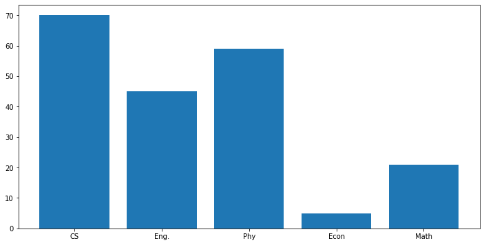

```python
plt.figure(figsize=(12,6))

discipline = ["CS", "Eng.", "Phy", "Econ", "Math"]
nb_studets = [70, 45, 59, 5, 21]

plt.bar(discipline, nb_studets)
```

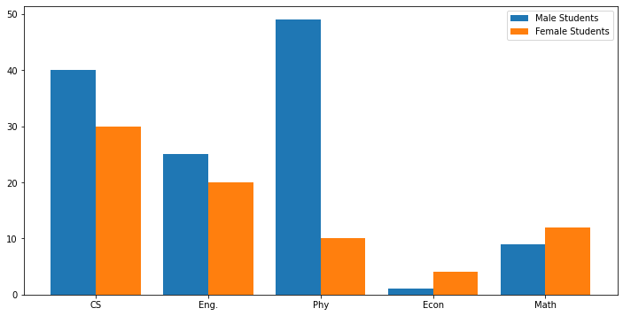

```python
plt.figure(figsize=(12,6))

bar_width = 0.4

discipline = ["CS", "Eng.", "Phy", "Econ", "Math"]
nb_male_studets = [40, 25, 49, 1, 9]
nb_female_studets = [30, 20, 10, 4, 12]

x_values = np.arange(len(discipline))

plt.bar(x_values - bar_width/2, nb_male_studets, width=bar_width, label="Male Students")
plt.bar(x_values + bar_width/2, nb_female_studets, width=bar_width, label="Female Students")

plt.xticks(x_values, discipline)
plt.legend()
```

### Basic Plot Types: Histogram

- A histogram shows the frequency of data within user-defined or automatically determined regions
- Histograms show the `distribution` of the data
  - The frequency (a proxy for probability) of different x-values
- Used when:
  - Data is `unidimensional`
  - Interested in showing the distribution of frequencies across bins

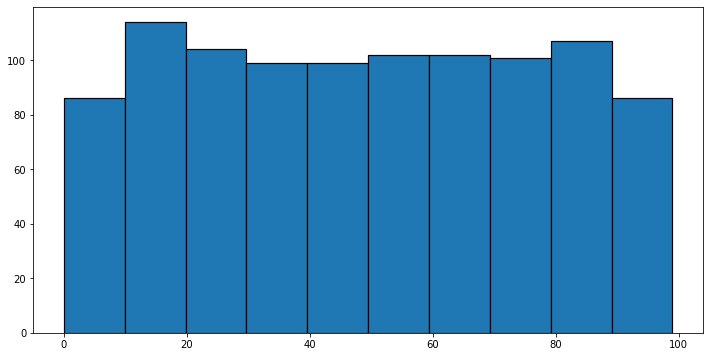

```python
plt.figure(figsize=(12,6))

data = np.random.randint(0, 100, 1000)

plt.hist(data, edgecolor='black', linewidth=1.2)
```

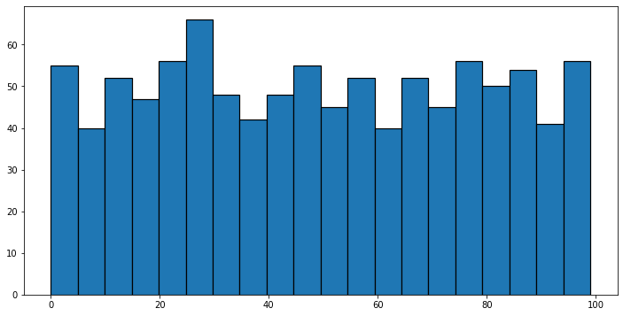

```python
plt.figure(figsize=(12,6))

data = np.random.randint(0, 100, 1000)

_ = plt.hist(data, bins = 20, edgecolor='black', linewidth=1.2)
```

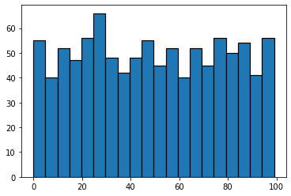

```python
plt.hist(data, bins = 20, edgecolor='black', linewidth=1.2)
```